# Time Series AF Shifts

Joe McGirr

2021-02-11

# 1 Summary

This notebook analyzes allele frequency shifts between Pacific Herring samples collected in 1991, 1996, 2006-7, and 2017. The summary statistic ∆z is the difference in arcsine square-root transformed minor allele frequencies (Following methods used for the [Longshanks experiment](https://elifesciences.org/articles/42014#s4)).

The data set is a filtered `.vcf` with 200k SNPs across 892 Pacific herring low coverage genomes:

minimum depth = 600  
maximum depth = 2000  
minimum base quality = 20  
minimum mapping quality = 30  
minor allele frequency > 5%  
genotyping rate > 50% for each population (grouped by samping location and year)

`ph_filtered_snps_minDP600_maxDP2000_minQ20_minMQ30_NS0.5_maf0.05.vcf`

Written by Joe McGirr, postdoc in Andrew Whitehead’s lab.

# 2 Output allele frequncies from vcf

example script

```bash
#!/bin/bash

#SBATCH --job-name=BC17_freqs
#SBATCH --mem=8G
#SBATCH --ntasks=4
#SBATCH -e BC17_freqs_%A_%a.err
#SBATCH --time=1:00:00
#SBATCH --mail-user=jamcgirr@ucdavis.edu ##email you when job starts,ends,etc
#SBATCH --mail-type=ALL
#SBATCH -p high

module load bcftools
bcftools query -f '%CHROM %POS %AF\n' /home/jamcgirr/ph/data/vcfs/split_pops/maf05/population_BC17_ph_filtered_snps_minDP600_maxDP2000_minQ20_minMQ30_NS0.5_maf0.05.vcf.gz > /home/jamcgirr/ph/data/freqs/population_BC17_ph_filtered_snps_minDP600_maxDP2000_minQ20_minMQ30_NS0.5_maf0.05_freqs.txt


#command to run: sbatch script_BC17_freqs.sh
```

## 2.1 Generate scripts

```python
# get allele frequencies for arcsine transformed shifts
job_name = '_freqs'

infiles = ["BC17","CA17","PWS07","PWS17","PWS91","PWS96","SS06","SS17","SS96","TB06","TB17","TB91","TB96","WA17"]
vcf_name = 'ph_filtered_snps_minDP600_maxDP2000_minQ20_minMQ30_NS0.5_maf0.05'
for infile in infiles:
    script = 'script_' + infile + job_name + '.sh'
    sbatch_header_loop(job_name,'8','4','1', infile)
    o = io.open(script,'a+', newline='\n')

    o.write('module load bcftools\n')

    o.write('bcftools query -f \'%CHROM %POS %AF\\n\' /home/jamcgirr/ph/data/vcfs/split_pops/maf05/population_'+infile+'_'+vcf_name+'.vcf.gz > /home/jamcgirr/ph/data/freqs/population_'+infile+'_'+vcf_name+'_freqs.txt \n')

    o.write('\n\n#command to run: sbatch '+script)
    o.close()

# calculate direct from AC and AN
#bcftools query -f '%CHROM %POS %AN %AC{0}\n' /home/jamcgirr/ph/data/vcfs/split_pops/population_PWS07_ph_filtered_snps_minDP600_maxDP2000_maf0.05_minQ20_minMQ30_maxmiss0.5_plates_1_5_rm.vcf > /home/jamcgirr/ph/data/freqs/PWS07_freqs_test.txt
```

# 3 Transform AFs and average across sliding windows

```r
#AF is calculated as AC/AN, where AC is total ALT allele count and AN is total allele called in genotypes

t0 <- read.table("C:/Users/jmcgirr/Documents/Whitehead_Lab/ph/freqs/population_PWS91_ph_filtered_snps_minDP600_maxDP2000_minQ20_minMQ30_NS0.5_maf0.05_freqs.txt", header = FALSE, stringsAsFactors = FALSE, col.names = c("chr","pos","t0_AF"))
t1 <- read.table("C:/Users/jmcgirr/Documents/Whitehead_Lab/ph/freqs/population_PWS96_ph_filtered_snps_minDP600_maxDP2000_minQ20_minMQ30_NS0.5_maf0.05_freqs.txt", header = FALSE, stringsAsFactors = FALSE, col.names = c("chr","pos","t1_AF"))
t2 <- read.table("C:/Users/jmcgirr/Documents/Whitehead_Lab/ph/freqs/population_PWS07_ph_filtered_snps_minDP600_maxDP2000_minQ20_minMQ30_NS0.5_maf0.05_freqs.txt", header = FALSE, stringsAsFactors = FALSE, col.names = c("chr","pos","t2_AF"))
t3 <- read.table("C:/Users/jmcgirr/Documents/Whitehead_Lab/ph/freqs/population_PWS17_ph_filtered_snps_minDP600_maxDP2000_minQ20_minMQ30_NS0.5_maf0.05_freqs.txt", header = FALSE, stringsAsFactors = FALSE, col.names = c("chr","pos","t3_AF"))


t0 <- read.table("C:/Users/jmcgirr/Documents/Whitehead_Lab/ph/freqs/population_TB91_ph_filtered_snps_minDP600_maxDP2000_minQ20_minMQ30_NS0.5_maf0.05_freqs.txt", header = FALSE, stringsAsFactors = FALSE, col.names = c("chr","pos","t0_AF"))
t1 <- read.table("C:/Users/jmcgirr/Documents/Whitehead_Lab/ph/freqs/population_TB96_ph_filtered_snps_minDP600_maxDP2000_minQ20_minMQ30_NS0.5_maf0.05_freqs.txt", header = FALSE, stringsAsFactors = FALSE, col.names = c("chr","pos","t1_AF"))
t2 <- read.table("C:/Users/jmcgirr/Documents/Whitehead_Lab/ph/freqs/population_TB06_ph_filtered_snps_minDP600_maxDP2000_minQ20_minMQ30_NS0.5_maf0.05_freqs.txt", header = FALSE, stringsAsFactors = FALSE, col.names = c("chr","pos","t2_AF"))
t3 <- read.table("C:/Users/jmcgirr/Documents/Whitehead_Lab/ph/freqs/population_TB17_ph_filtered_snps_minDP600_maxDP2000_minQ20_minMQ30_NS0.5_maf0.05_freqs.txt", header = FALSE, stringsAsFactors = FALSE, col.names = c("chr","pos","t3_AF"))


freqs <- data.frame(chr = t0$chr,
                    pos = t0$pos,
                    t0_AF = t0$t0_AF,
                    t1_AF = t1$t1_AF,
                    t2_AF = t2$t2_AF,
                    t3_AF = t3$t3_AF)

freqs$t0_transformed_freq <- asin(sqrt(freqs$t0_AF))
freqs$t1_transformed_freq <- asin(sqrt(freqs$t1_AF))
freqs$t2_transformed_freq <- asin(sqrt(freqs$t2_AF))
freqs$t3_transformed_freq <- asin(sqrt(freqs$t3_AF))

freqs$zt01 <- freqs$t1_transformed_freq - freqs$t0_transformed_freq
freqs$zt02 <- freqs$t2_transformed_freq - freqs$t0_transformed_freq
freqs$zt03 <- freqs$t3_transformed_freq - freqs$t0_transformed_freq
freqs$zt12 <- freqs$t2_transformed_freq - freqs$t1_transformed_freq
freqs$zt13 <- freqs$t3_transformed_freq - freqs$t1_transformed_freq
freqs$zt23 <- freqs$t3_transformed_freq - freqs$t2_transformed_freq


head(freqs)
nrow(freqs)
#write.table(freqs, "C:/Users/jmcgirr/Documents/Whitehead_Lab/ph/freqs/persite/TB_shifts_persite.txt")


freqs_win <- winScan(x = freqs,
                   groups = "chr",
                   position = "pos",
                   values = c("zt01","zt02","zt03","zt12","zt13","zt23"),
                   win_size = 50000,
                   win_step = 10000,
                   funs = c("mean"))
freqs_win <- na.omit(freqs_win)
freqs_win <- freqs_win %>% mutate(chr = as.numeric(gsub("chr", "", chr)))
freqs_win$chr_num <- factor(freqs_win$chr, levels = c(1:26))

#write.table(freqs_win, "C:/Users/jmcgirr/Documents/Whitehead_Lab/ph/freqs/window/TB_shifts_50kb_win_10kb_step.txt")
```

# 4 Example of genome-wide allele frequency shifts for PWS 1991 –> 1996

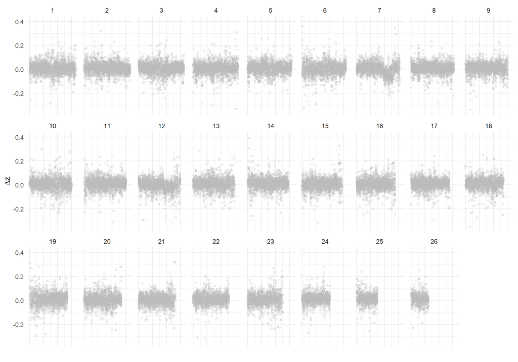

```r
pop <- "PWS"
freqs_win <- read.table(paste("C:/Users/jmcgirr/Documents/Whitehead_Lab/ph/freqs/window/",pop,"_shifts_50kb_win_10kb_step.txt", sep = ""))
freqs_win$chr_num <- factor(freqs_win$chr, levels = c(1:26))

p <- ggplot(freqs_win, aes(x = win_mid, y = zt01_mean)) +
     geom_point(size = 1, color = gry,alpha = 0.7, shape = 1)+
     theme_minimal()+
     theme(axis.text.x=element_blank())+
     ylab(expression(paste(Delta, "z")))+ xlab("")+
     #geom_smooth(method = "loess", se = FALSE, span = 1/10, color = blu)+
     facet_wrap(~chr_num, ncol = 9)
p
```

# 5 Compare magnitude of AF shifts between populations

Shows the distribution of ∆z for each population from

- 1991 –> 1996
- 1996 –> 2007
- 2007 –> 2017

Does ∆z center around zero? (expected under drift)

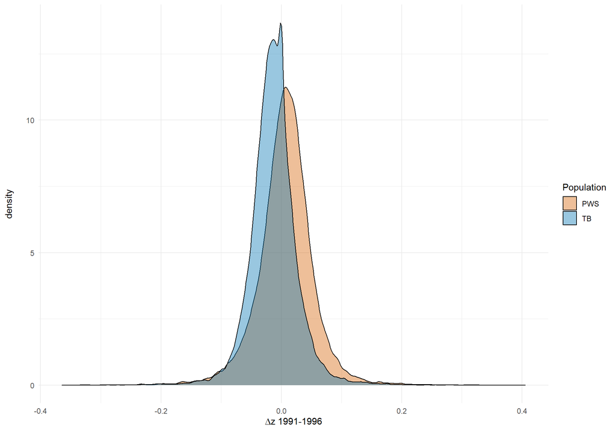

```r
freqs_win_p <- read.table("C:/Users/jmcgirr/Documents/Whitehead_Lab/ph/freqs/window/PWS_shifts_50kb_win_10kb_step.txt")
freqs_win_t <- read.table("C:/Users/jmcgirr/Documents/Whitehead_Lab/ph/freqs/window/TB_shifts_50kb_win_10kb_step.txt")
freqs_win_s <- read.table("C:/Users/jmcgirr/Documents/Whitehead_Lab/ph/freqs/window/SS_shifts_50kb_win_10kb_step.txt")

all_pops <- data.frame(chr = freqs_win_p$chr,
                       win_mid = freqs_win_p$win_mid,
                       zt01_p = freqs_win_p$zt01_mean,
                       zt02_p = freqs_win_p$zt02_mean,
                       zt03_p = freqs_win_p$zt03_mean,
                       zt12_p = freqs_win_p$zt12_mean,
                       zt13_p = freqs_win_p$zt13_mean,
                       zt23_p = freqs_win_p$zt23_mean,
                       zt01_t = freqs_win_t$zt01_mean,
                       zt02_t = freqs_win_t$zt02_mean,
                       zt03_t = freqs_win_t$zt03_mean,
                       zt12_t = freqs_win_t$zt12_mean,
                       zt13_t = freqs_win_t$zt13_mean,
                       zt23_t = freqs_win_t$zt23_mean,
                       zt12_s = freqs_win_s$zt12_mean,
                       zt13_s = freqs_win_s$zt13_mean,
                       zt23_s = freqs_win_s$zt23_mean)


all_pops$chr_num <- factor(all_pops$chr, levels = c(1:26))

zp <- data.frame(z91_96 = all_pops$zt01_p,pop = "PWS")
zt <- data.frame(z91_96 = all_pops$zt01_t,pop = "TB")
z <- rbind(zp,zt)

p<-ggplot(z, aes(x=z91_96, fill=pop)) +
   geom_density(alpha=0.4)+
   scale_fill_manual(name = "Population",values=c(red,blu))+
   ylab("density\n") + xlab(expression(paste(Delta, "z 1991-1996")))+
   theme_minimal()
p
```

[figure not shown]

```r
zp <- data.frame(z96_07 = all_pops$zt12_p,pop = "PWS")
zt <- data.frame(z96_07 = all_pops$zt12_t,pop = "TB")
zs <- data.frame(z96_07 = all_pops$zt12_s,pop = "SS")

z <- rbind(zp,zt,zs)

p<-ggplot(z, aes(x=z96_07, fill=pop)) +
   geom_density(alpha=0.4)+
   scale_fill_manual(name = "Population",values=c(red,yel,blu))+
   ylab("density\n") + xlab(expression(paste(Delta, "z 2007-2017")))+
   theme_minimal()
p
```

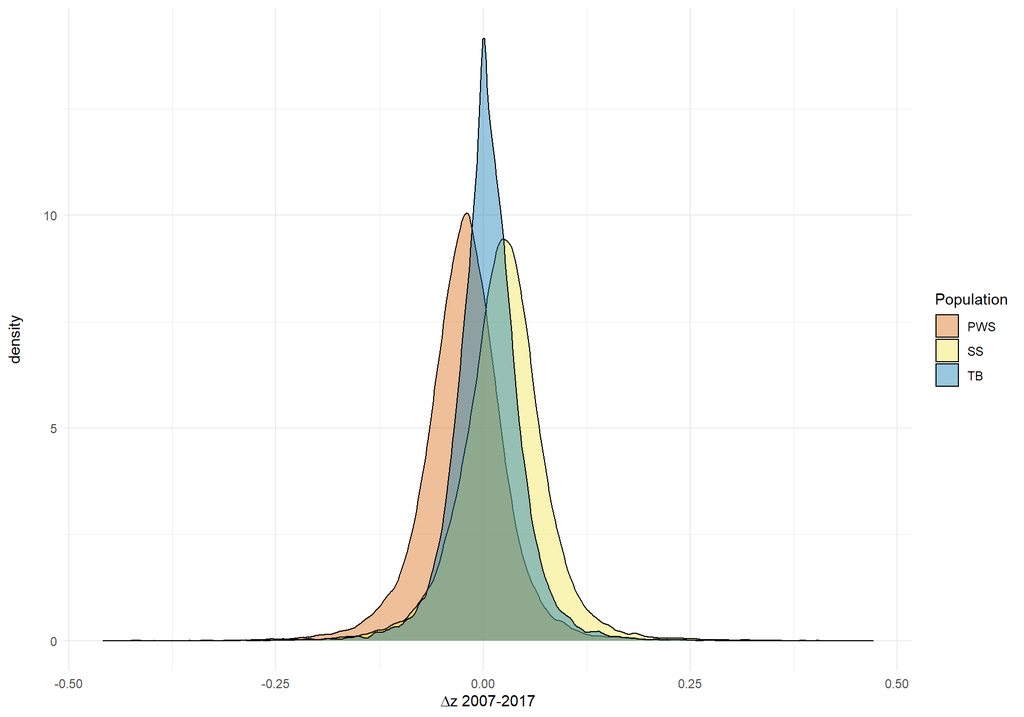

```r
zp <- data.frame(z07_17 = all_pops$zt23_p,pop = "PWS")
zt <- data.frame(z07_17 = all_pops$zt23_t,pop = "TB")
zs <- data.frame(z07_17 = all_pops$zt23_s,pop = "SS")

z <- rbind(zp,zt,zs)

p<-ggplot(z, aes(x=z07_17, fill=pop)) +
   geom_density(alpha=0.4)+
   scale_fill_manual(name = "Population",values=c(red,yel,blu))+
   ylab("density\n") + xlab(expression(paste(Delta, "z 2007-2017")))+
   theme_minimal()
p
```

# 6 Identify windows where allele frequencies showed shifts in the same direction

Out of 70234 50kb windows, what percentage consistently:

- increased between each sampling period
- decreased between each sampling period

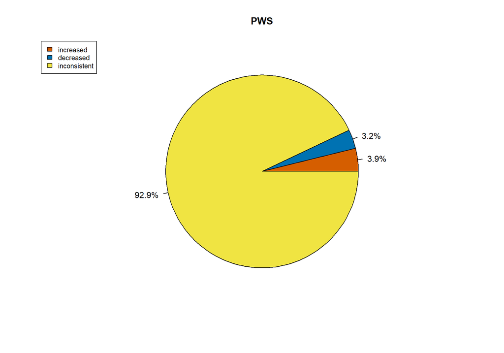

[output not shown]

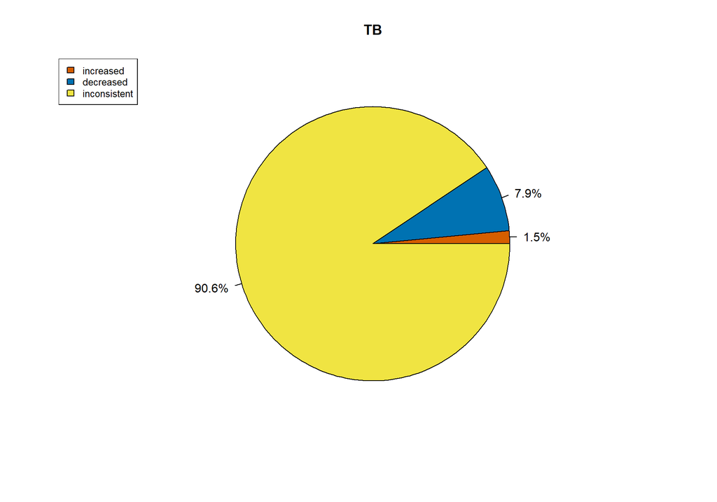

[output not shown]

```r
pops <- c("PWS","TB")
#pop <- "TB"

for (pop in pops){
freqs_win <- read.table(paste("C:/Users/jmcgirr/Documents/Whitehead_Lab/ph/freqs/window/",pop,"_shifts_50kb_win_10kb_step.txt", sep = ""))
freqs_win$chr_num <- factor(freqs_win$chr, levels = c(1:26))


# identify windows where allele frequencies increased between each sampling period
increased_freq <- freqs_win[freqs_win$zt01_mean > 0 &
                            freqs_win$zt12_mean > 0 &
                            freqs_win$zt23_mean > 0,]
#nrow(increased_freq)
#nrow(increased_freq) / nrow(freqs_win)
# identify windows where allele frequencies increased between each sampling period
decreased_freq <- freqs_win[freqs_win$zt01_mean < 0 &
                            freqs_win$zt12_mean < 0 &
                            freqs_win$zt23_mean < 0,]
#nrow(decreased_freq)
#nrow(decreased_freq) / nrow(freqs_win)

inc <- nrow(increased_freq)
dec <- nrow(decreased_freq)
remain <- nrow(freqs_win)-(inc+dec)

p <- pie(c(inc,dec,remain), col = c(red, blu, yel), main = pop,
      labels = c(paste(round(inc/nrow(freqs_win),3)*100, "%", sep = ""),
                 paste(round(dec/nrow(freqs_win),3)*100, "%", sep = ""),
                 paste(round(remain/nrow(freqs_win),3)*100, "%", sep = "")))

l <- legend("topleft", c("increased", "decreased", "inconsistent"), cex = 0.8,
   fill = c(red, blu, yel))
print(p)
print(l)

}
```

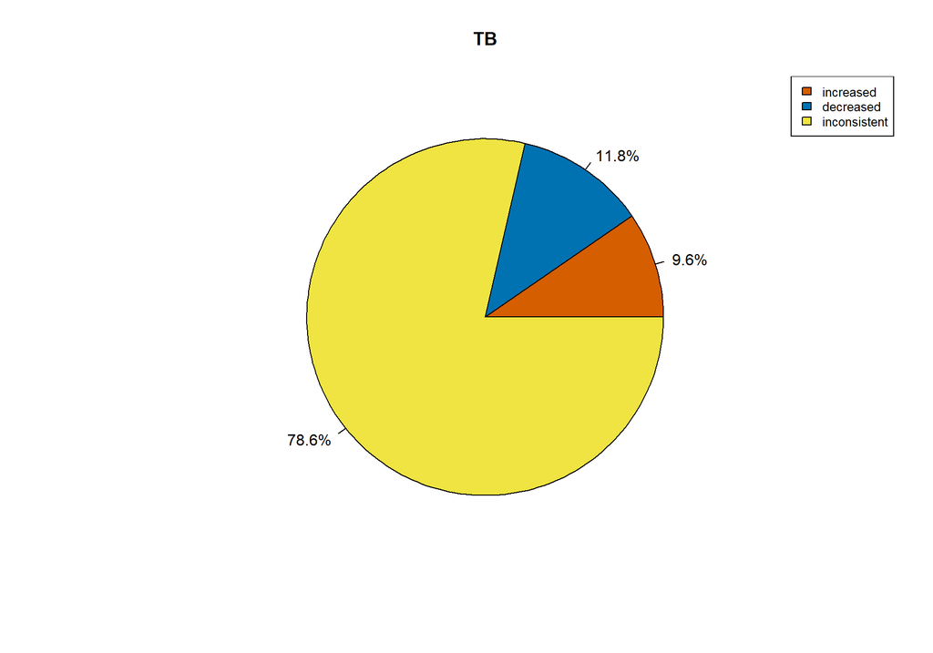

```r
freqs_win <- read.table("C:/Users/jmcgirr/Documents/Whitehead_Lab/ph/freqs/window/SS_shifts_50kb_win_10kb_step.txt")
freqs_win$chr_num <- factor(freqs_win$chr, levels = c(1:26))


# identify windows where allele frequencies increased between each sampling period
increased_freq <- freqs_win[freqs_win$zt12_mean > 0 &
                            freqs_win$zt23_mean > 0,]
#nrow(increased_freq)
#nrow(increased_freq) / nrow(freqs_win)
# identify windows where allele frequencies increased between each sampling period
decreased_freq <- freqs_win[freqs_win$zt12_mean < 0 &
                            freqs_win$zt23_mean < 0,]
#nrow(decreased_freq)
#nrow(decreased_freq) / nrow(freqs_win)

inc <- nrow(increased_freq)
dec <- nrow(decreased_freq)
remain <- nrow(freqs_win)-(inc+dec)
pie(c(inc,dec,remain), col = c(red, blu, yel), main = pop,
    labels = c(paste(round(inc/nrow(freqs_win),3)*100, "%", sep = ""),
               paste(round(dec/nrow(freqs_win),3)*100, "%", sep = ""),
               paste(round(remain/nrow(freqs_win),3)*100, "%", sep = "")))
legend("topright", c("increased", "decreased", "inconsistent"), cex = 0.8,
   fill = c(red, blu, yel))
```

# 7 Identify windows where allele frequencies showed LARGE shifts in the same direction:

Are there any windows that show: - ∆z > 90th percentile across all sampling periods - ∆z < 10th percentile across all sampling periods

```
## [1] "TB increased"
## [1] "TB decreased"
```

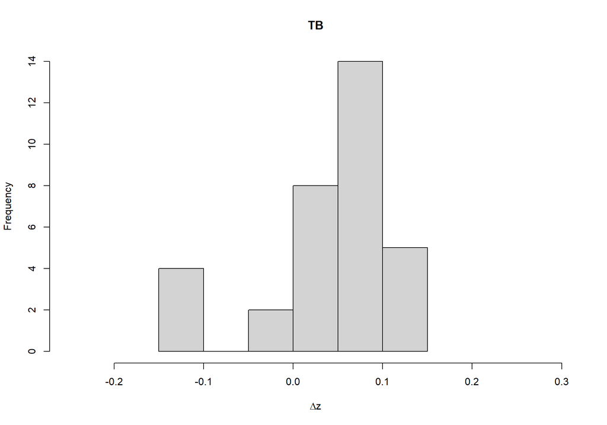

```
## $breaks
## [1] -0.15 -0.10 -0.05  0.00  0.05  0.10  0.15
##
## $counts
## [1]  4  0  2  8 14  5
##
## $density
## [1] 2.424242 0.000000 1.212121 4.848485 8.484848 3.030303
##
## $mids
## [1] -0.125 -0.075 -0.025  0.025  0.075  0.125
##
## $xname
## [1] "c(top_increased$zt01_mean, top_increased$zt12_mean, top_increased$zt23_mean, top_decreased$zt01_mean, top_decreased$zt12_mean, top_decreased$zt23_mean)"
##
## $equidist
## [1] TRUE
##
## attr(,"class")
## [1] "histogram"
## [1] "PWS increased"
## [1] "PWS decreased"
```

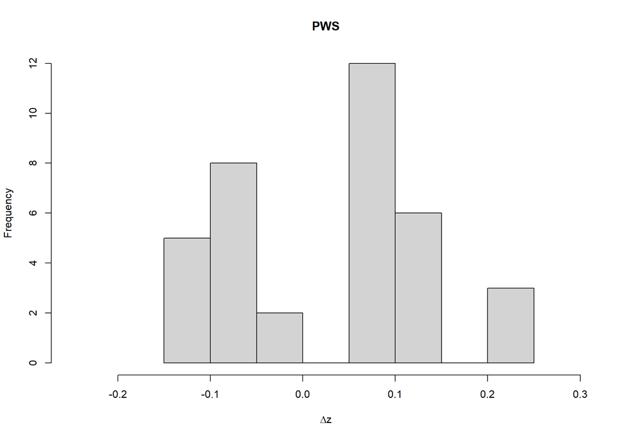

```
## $breaks
## [1] -0.15 -0.10 -0.05  0.00  0.05  0.10  0.15  0.20  0.25
##
## $counts
## [1]  5  8  2  0 12  6  0  3
##
## $density
## [1] 2.777778 4.444444 1.111111 0.000000 6.666667 3.333333 0.000000 1.666667
##
## $mids
## [1] -0.125 -0.075 -0.025  0.025  0.075  0.125  0.175  0.225
##
## $xname
## [1] "c(top_increased$zt01_mean, top_increased$zt12_mean, top_increased$zt23_mean, top_decreased$zt01_mean, top_decreased$zt12_mean, top_decreased$zt23_mean)"
##
## $equidist
## [1] TRUE
##
## attr(,"class")
## [1] "histogram"
```

```r
pops <- c("TB","PWS")
#pop <- "PWS"

for (pop in pops){
freqs_win <- read.table(paste("C:/Users/jmcgirr/Documents/Whitehead_Lab/ph/freqs/window/",pop,"_shifts_50kb_win_10kb_step.txt", sep = ""))
freqs_win$chr_num <- factor(freqs_win$chr, levels = c(1:26))

# identify windows where allele frequencies increased between each sampling period
top_increased <- freqs_win[freqs_win$zt01_mean >= quantile(freqs_win$zt01_mean, .9)[[1]] &
                           freqs_win$zt12_mean >= quantile(freqs_win$zt12_mean, .9)[[1]] &
                           freqs_win$zt23_mean >= quantile(freqs_win$zt23_mean, .9)[[1]],]

# identify windows where allele frequencies decreased between each sampling period
top_decreased <- freqs_win[freqs_win$zt01_mean <= quantile(freqs_win$zt01_mean, .1)[[1]] &
                           freqs_win$zt12_mean <= quantile(freqs_win$zt12_mean, .1)[[1]] &
                           freqs_win$zt23_mean <= quantile(freqs_win$zt23_mean, .1)[[1]],]

print(paste(pop,"increased"))
top_increased# / nrow(freqs_win)
print(paste(pop,"decreased"))
top_decreased# / nrow(freqs_win)

print(hist(c(top_increased$zt01_mean,
       top_increased$zt12_mean,
       top_increased$zt23_mean,
       top_decreased$zt01_mean,
       top_decreased$zt12_mean,
       top_decreased$zt23_mean), xlab = expression(paste(Delta, "z")),
       main = pop, xlim = c(-0.25, 0.3)))

}
```

## 7.1 PWS chr 18 (windows with strongest positive shift across all sampling periods)

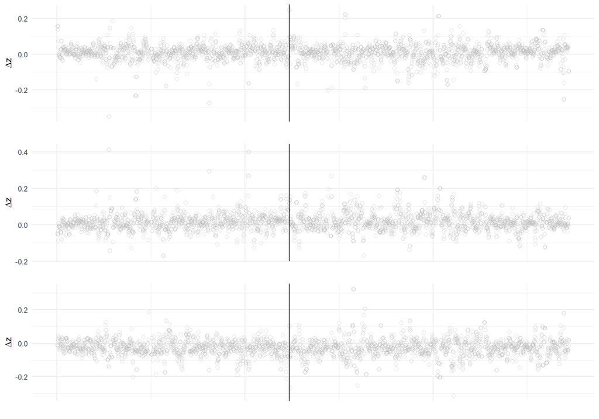

```r
pop <- "PWS"

freqs_win <- read.table(paste("C:/Users/jmcgirr/Documents/Whitehead_Lab/ph/freqs/window/",pop,"_shifts_50kb_win_10kb_step.txt", sep = ""))
freqs_win$chr_num <- factor(freqs_win$chr, levels = c(1:26))

# identify windows where allele frequencies increased between each sampling period
top_increased <- freqs_win[freqs_win$zt01_mean >= quantile(freqs_win$zt01_mean, .9)[[1]] &
                           freqs_win$zt12_mean >= quantile(freqs_win$zt12_mean, .9)[[1]] &
                           freqs_win$zt23_mean >= quantile(freqs_win$zt23_mean, .9)[[1]],]

# identify windows where allele frequencies decreased between each sampling period
top_decreased <- freqs_win[freqs_win$zt01_mean <= quantile(freqs_win$zt01_mean, .1)[[1]] &
                           freqs_win$zt12_mean <= quantile(freqs_win$zt12_mean, .1)[[1]] &
                           freqs_win$zt23_mean <= quantile(freqs_win$zt23_mean, .1)[[1]],]

# PWS chr with strongest positive shift (18)

freqs_win1 <- freqs_win[freqs_win$chr == "18",]
top_increased1 <- top_increased[top_increased$chr == "18",]

p01 <- ggplot(freqs_win1, aes(x = win_mid, y = zt01_mean)) +
     geom_point(size = 2, color = gry,alpha = 0.6, shape = 1)+
     theme_minimal()+
     theme(axis.text.x=element_blank())+
     ylab(expression(paste(Delta, "z")))+ xlab("")+
     geom_vline(aes(xintercept = win_mid), top_increased1)
p12 <- ggplot(freqs_win1, aes(x = win_mid, y = zt12_mean)) +
     geom_point(size = 2, color = gry,alpha = 0.6, shape = 1)+
     theme_minimal()+
     theme(axis.text.x=element_blank())+
     ylab(expression(paste(Delta, "z")))+ xlab("")+
     geom_vline(aes(xintercept = win_mid), top_increased1)
p23 <- ggplot(freqs_win1, aes(x = win_mid, y = zt23_mean)) +
     geom_point(size = 2, color = gry,alpha = 0.6, shape = 1)+
     theme_minimal()+
     theme(axis.text.x=element_blank())+
     ylab(expression(paste(Delta, "z")))+ xlab("")+
     geom_vline(aes(xintercept = win_mid), top_increased1)

#p + geom_vline(aes(xintercept = win_mid), tops)

ggarrange(p01,p12,p23, ncol = 1, nrow = 3)#,
```

```r
          #labels = c("A", "B", "C"))

# Find genes in regions

gff <- read.delim("C:/Users/jmcgirr/Documents/Whitehead_Lab/ph/annotations/Clupea_harengus.Ch_v2.0.2.100.gff3",header = FALSE, sep = "\t",comment.char = '#')
#head(gff)
colnames(gff) <- c("seqnames","source","type","start","end","score","strand","phase","attributes")
genes <- gff[gff$type=="gene",]
genes <- genes %>% separate(attributes, c("at1","at2"), remove = FALSE,sep = "Name=") %>% separate(at2, c("gene_name","at3"), extra = "drop",sep = ";")
genes <- select(genes, -at1,-at3)
g <- genes[genes$strand == "\\.",]
#head(genes)
genes <- droplevels(genes)

genes <- genes %>% as_granges()

names(top_increased)[names(top_increased) == "chr"] <- "seqnames"
names(top_increased)[names(top_increased) == "win_start"] <- "start"
names(top_increased)[names(top_increased) == "win_end"] <- "end"

names(top_decreased)[names(top_decreased) == "chr"] <- "seqnames"
names(top_decreased)[names(top_decreased) == "win_start"] <- "start"
names(top_decreased)[names(top_decreased) == "win_end"] <- "end"


tops <- rbind(top_increased,top_decreased)

tops<- tops %>% as_granges()

genes_overlap <- join_overlap_intersect(tops, genes) %>% as.data.frame()

#write.table(as.data.frame(unique(na.omit(focal_chr_genes$gene_name))), "C:/Users/jmcgirr/Documents/Whitehead_Lab/ph/GO/fst_outliers/PWS17_v_TB17_Fst_99percentile_genes.txt", quote= FALSE, row.names = FALSE, col.names = FALSE)
```

# 8 Identify windows where allele frequencies showed large shifts after collapse and reversed over time:

- increased between 91 and 96, decreased between 96 and 07, and continued to decrease between 07 and 17
- decreased between 91 and 96, increased between 96 and 07, and continued to increase between 07 and 17

```
## [1] "TB up_dn_dn"
## [1] "TB dn_up_up"
```

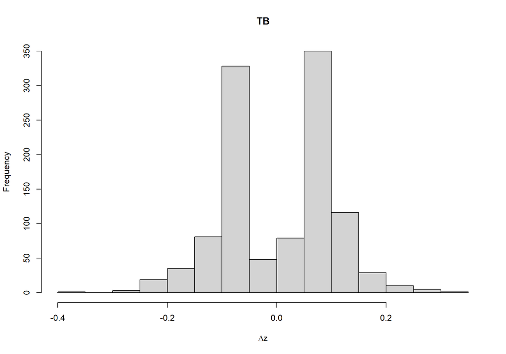

```
## $breaks
##  [1] -0.40 -0.35 -0.30 -0.25 -0.20 -0.15 -0.10 -0.05  0.00  0.05  0.10  0.15
## [13]  0.20  0.25  0.30  0.35
##
## $counts
##  [1]   1   0   3  19  35  81 328  48  79 350 116  29  10   4   1
##
## $density
##  [1] 0.01811594 0.00000000 0.05434783 0.34420290 0.63405797 1.46739130
##  [7] 5.94202899 0.86956522 1.43115942 6.34057971 2.10144928 0.52536232
## [13] 0.18115942 0.07246377 0.01811594
##
## $mids
##  [1] -0.375 -0.325 -0.275 -0.225 -0.175 -0.125 -0.075 -0.025  0.025  0.075
## [11]  0.125  0.175  0.225  0.275  0.325
##
## $xname
## [1] "c(up_dn_dn$zt01_mean, up_dn_dn$zt12_mean, up_dn_dn$zt23_mean, dn_up_up$zt01_mean, dn_up_up$zt12_mean, dn_up_up$zt23_mean)"
##
## $equidist
## [1] TRUE
##
## attr(,"class")
## [1] "histogram"
## [1] "PWS up_dn_dn"
## [1] "PWS dn_up_up"
```

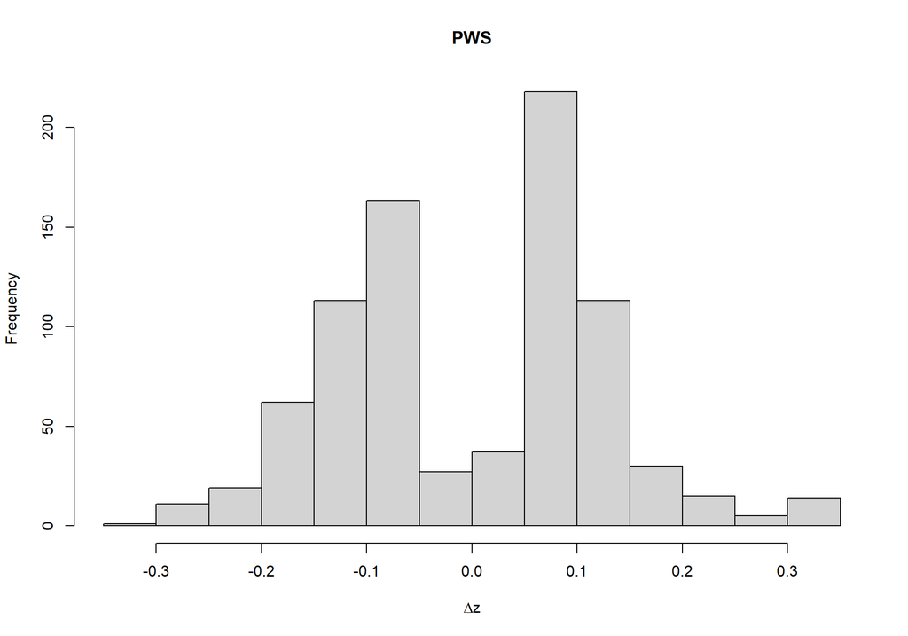

```
## $breaks
##  [1] -0.35 -0.30 -0.25 -0.20 -0.15 -0.10 -0.05  0.00  0.05  0.10  0.15  0.20
## [13]  0.25  0.30  0.35
##
## $counts
##  [1]   1  11  19  62 113 163  27  37 218 113  30  15   5  14
##
## $density
##  [1] 0.02415459 0.26570048 0.45893720 1.49758454 2.72946860 3.93719807
##  [7] 0.65217391 0.89371981 5.26570048 2.72946860 0.72463768 0.36231884
## [13] 0.12077295 0.33816425
##
## $mids
##  [1] -0.325 -0.275 -0.225 -0.175 -0.125 -0.075 -0.025  0.025  0.075  0.125
## [11]  0.175  0.225  0.275  0.325
##
## $xname
## [1] "c(up_dn_dn$zt01_mean, up_dn_dn$zt12_mean, up_dn_dn$zt23_mean, dn_up_up$zt01_mean, dn_up_up$zt12_mean, dn_up_up$zt23_mean)"
##
## $equidist
## [1] TRUE
##
## attr(,"class")
## [1] "histogram"
```

```r
pops <- c("TB","PWS")
#pop <- "PWS"

for (pop in pops){
freqs_win <- read.table(paste("C:/Users/jmcgirr/Documents/Whitehead_Lab/ph/freqs/window/",pop,"_shifts_50kb_win_10kb_step.txt", sep = ""))
freqs_win$chr_num <- factor(freqs_win$chr, levels = c(1:26))

# identify windows where allele frequencies increased between 91 and 96
# and decreased between 96 and 07
# and continued to decrease between 07 and 17
up_dn_dn <- freqs_win[freqs_win$zt01_mean >= quantile(freqs_win$zt01_mean, .9)[[1]] &
                               freqs_win$zt12_mean <= quantile(freqs_win$zt12_mean, .1)[[1]] &
                               freqs_win$zt23_mean <= quantile(freqs_win$zt23_mean, .1)[[1]],]

# identify windows where allele frequencies decreased between 91 and 96
# and increased between 96 and 07
# and continued to increase between 07 and 17
dn_up_up <- freqs_win[freqs_win$zt01_mean <= quantile(freqs_win$zt01_mean, .1)[[1]] &
                               freqs_win$zt12_mean >= quantile(freqs_win$zt12_mean, .9)[[1]] &
                               freqs_win$zt23_mean >= quantile(freqs_win$zt23_mean, .9)[[1]],]

print(paste(pop,"up_dn_dn"))
up_dn_dn# / nrow(freqs_win)
print(paste(pop,"dn_up_up"))
dn_up_up# / nrow(freqs_win)

print(hist(c(up_dn_dn$zt01_mean,
             up_dn_dn$zt12_mean,
             up_dn_dn$zt23_mean,
             dn_up_up$zt01_mean,
             dn_up_up$zt12_mean,
             dn_up_up$zt23_mean), xlab = expression(paste(Delta, "z")),
             main = pop))#, xlim = c(-0.25, 0.3)))

}
```

# 9 Fst matrix temporal samples (within population comparisons)

## 9.1 PWS

```r
fst <- read.delim("C:/Users/jmcgirr/Documents/Whitehead_Lab/ph/fst_pbs/maf05/fst_pbs_50kb_win_10kb_step_folded_PWS91_PWS96_PWS07.txt")
p91xp96 <- round(mean(fst$Fst01),4)
p91xp07 <- round(mean(fst$Fst02),4)
p96xp07 <- round(mean(fst$Fst12),4)
fst <- read.delim("C:/Users/jmcgirr/Documents/Whitehead_Lab/ph/fst_pbs/maf05/fst_pbs_50kb_win_10kb_step_folded_PWS91_PWS96_PWS17.txt")
p91xp17 <- round(mean(fst$Fst02),4)
p96xp17 <- round(mean(fst$Fst12),4)
fst <- read.delim("C:/Users/jmcgirr/Documents/Whitehead_Lab/ph/fst_pbs/maf05/fst_pbs_50kb_win_10kb_step_folded_PWS91_PWS07_PWS17.txt")
p07xp17 <- round(mean(fst$Fst12),4)

fst_vec <- c(0,p91xp96,p91xp07,p91xp17,
             p91xp96,0,p96xp07,p96xp17,
             p91xp07,p96xp07,0,p07xp17,
             p91xp17,p96xp17,p07xp17,0)

fst_mat = matrix(fst_vec, nrow = 4, ncol = 4)
colnames(fst_mat) <- c("PWS91","PWS96","PWS07","PWS17")
rownames(fst_mat) <- c("PWS91","PWS96","PWS07","PWS17")
print(fst_mat)
```

```
##        PWS91  PWS96  PWS07  PWS17
## PWS91 0.0000 0.0071 0.0102 0.0079
## PWS96 0.0071 0.0000 0.0089 0.0075
## PWS07 0.0102 0.0089 0.0000 0.0108
## PWS17 0.0079 0.0075 0.0108 0.0000
```

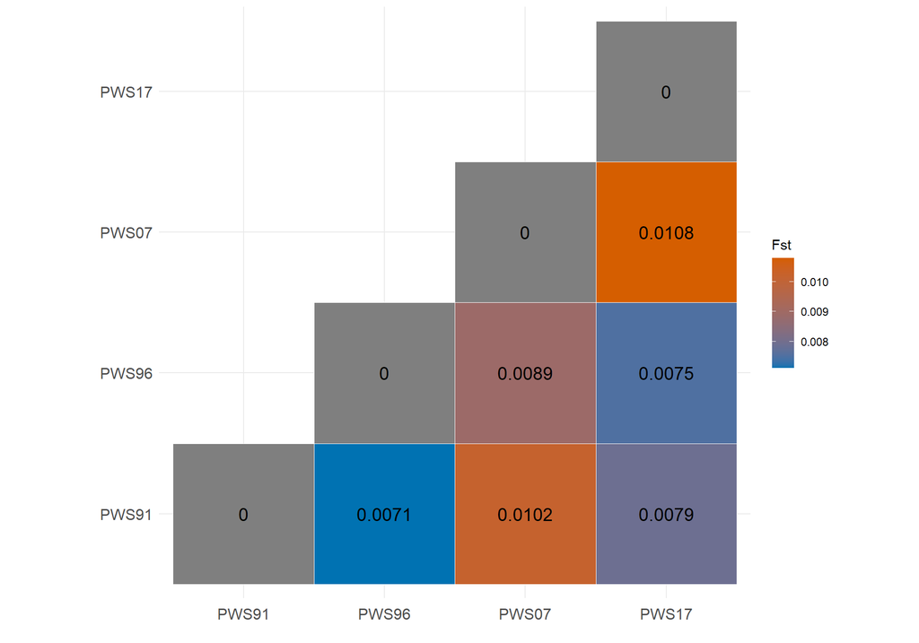

```r
upper_tri <- get_upper_tri(fst_mat)

melted_cormat <- melt(upper_tri, na.rm = TRUE)
ggplot(data = melted_cormat, aes(Var2, Var1, fill = value))+
 geom_tile(color = "white")+
 scale_fill_gradient(low = blu, high = red,
    limit = c(min(c(fst_mat)[c(fst_mat) > 0]),max(fst_mat)), space = "Lab",
   name="Fst") +
  theme_minimal()+ xlab("")+ylab("")+
 theme(axis.text.x = element_text(angle = 0, vjust = 0,
    size = 12, hjust = 0.5))+
   theme(axis.text.y = element_text(size = 12))+
 coord_fixed()+
 geom_text(aes(Var2, Var1, label = value), color = "black", size = 5)
```

## 9.2 TB

```r
fst <- read.delim("C:/Users/jmcgirr/Documents/Whitehead_Lab/ph/fst_pbs/maf05/fst_pbs_50kb_win_10kb_step_folded_TB91_TB96_TB06.txt")
p91xp96 <- round(mean(fst$Fst01),4)
p91xp07 <- round(mean(fst$Fst02),4)
p96xp07 <- round(mean(fst$Fst12),4)
fst <- read.delim("C:/Users/jmcgirr/Documents/Whitehead_Lab/ph/fst_pbs/maf05/fst_pbs_50kb_win_10kb_step_folded_TB91_TB96_TB17.txt")
p91xp17 <- round(mean(fst$Fst02),4)
p96xp17 <- round(mean(fst$Fst12),4)
fst <- read.delim("C:/Users/jmcgirr/Documents/Whitehead_Lab/ph/fst_pbs/maf05/fst_pbs_50kb_win_10kb_step_folded_TB91_TB06_TB17.txt")
p07xp17 <- round(mean(fst$Fst12),4)

fst_vec <- c(0,p91xp96,p91xp07,p91xp17,
            p91xp96,0,p96xp07,p96xp17,
            p91xp07,p96xp07,0,p07xp17,
            p91xp17,p96xp17,p07xp17,0)

fst_mat = matrix(fst_vec, nrow = 4, ncol = 4)
colnames(fst_mat) <- c("TB91","TB96","TB06","TB17")
rownames(fst_mat) <- c("TB91","TB96","TB06","TB17")
print(fst_mat)
```

```
##        TB91   TB96   TB06   TB17
## TB91 0.0000 0.0077 0.0099 0.0086
## TB96 0.0077 0.0000 0.0091 0.0073
## TB06 0.0099 0.0091 0.0000 0.0093
## TB17 0.0086 0.0073 0.0093 0.0000
```

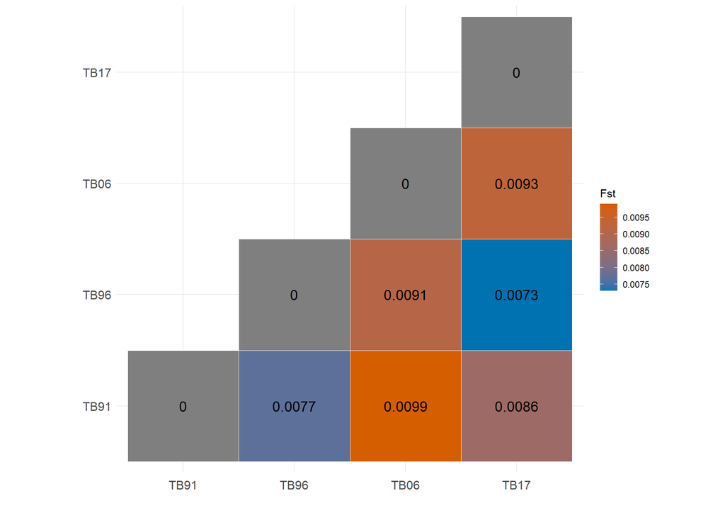

```r
upper_tri <- get_upper_tri(fst_mat)

melted_cormat <- melt(upper_tri, na.rm = TRUE)
ggplot(data = melted_cormat, aes(Var2, Var1, fill = value))+
 geom_tile(color = "white")+
 scale_fill_gradient(low = blu, high = red,
    limit = c(min(c(fst_mat)[c(fst_mat) > 0]),max(fst_mat)), space = "Lab",
   name="Fst") +
  theme_minimal()+ xlab("")+ylab("")+
 theme(axis.text.x = element_text(angle = 0, vjust = 0,
    size = 12, hjust = 0.5))+
   theme(axis.text.y = element_text(size = 12))+
 coord_fixed()+
 geom_text(aes(Var2, Var1, label = value), color = "black", size = 5)
```

## 9.3 SS

```r
fst <- read.delim("C:/Users/jmcgirr/Documents/Whitehead_Lab/ph/fst_pbs/maf05/fst_pbs_50kb_win_10kb_step_folded_SS96_SS06_SS17.txt")
p96xp07 <- round(mean(fst$Fst01),4)
p96xp17 <- round(mean(fst$Fst02),4)
p07xp17 <- round(mean(fst$Fst12),4)


fst_vec <- c(0,p96xp07,p96xp17,
            p96xp07,0,p07xp17,
            p96xp17,p07xp17,0)

fst_mat = matrix(fst_vec, nrow = 3, ncol = 3)
colnames(fst_mat) <- c("SS96","SS06","SS17")
rownames(fst_mat) <- c("SS96","SS06","SS17")
print(fst_mat)
```

```
##        SS96   SS06   SS17
## SS96 0.0000 0.0092 0.0062
## SS06 0.0092 0.0000 0.0098
## SS17 0.0062 0.0098 0.0000
```

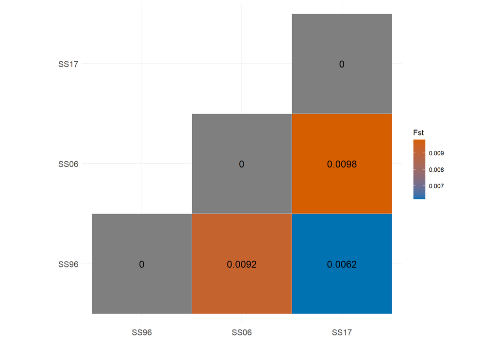

```r
upper_tri <- get_upper_tri(fst_mat)

melted_cormat <- melt(upper_tri, na.rm = TRUE)
ggplot(data = melted_cormat, aes(Var2, Var1, fill = value))+
 geom_tile(color = "white")+
 scale_fill_gradient(low = blu, high = red,
    limit = c(min(c(fst_mat)[c(fst_mat) > 0]),max(fst_mat)), space = "Lab",
   name="Fst") +
  theme_minimal()+ xlab("")+ylab("")+
 theme(axis.text.x = element_text(angle = 0, vjust = 0,
    size = 12, hjust = 0.5))+
   theme(axis.text.y = element_text(size = 12))+
 coord_fixed()+
 geom_text(aes(Var2, Var1, label = value), color = "black", size = 5)
```

# 10 PWS Fst windows

Which loci are consistently differentiated between sampling periods

Find windows that show high Fst in 1991 v 1996, 1996 v 2007, and 2007 - 2017 comparisons

```r
fsts <- list.files(path="C:/Users/jmcgirr/Documents/Whitehead_Lab/ph/fst_pbs/maf05/", full.names=T)
#fsts <- fsts[1]


fst <- read.table("C:/Users/jmcgirr/Documents/Whitehead_Lab/ph/fst_pbs/maf05/fst_pbs_50kb_win_10kb_step_folded_PWS91_PWS96_PWS07.txt", header = TRUE, stringsAsFactors = FALSE)
fst2 <- read.table("C:/Users/jmcgirr/Documents/Whitehead_Lab/ph/fst_pbs/maf05/fst_pbs_50kb_win_10kb_step_folded_PWS91_PWS07_PWS17.txt", header = TRUE, stringsAsFactors = FALSE)
names(fst2) <- c("region","chr","midPos","Nsites","Fst02","Fst03","Fst23","PBS0","PBS2","PBS3")
#fst1 <- read.table("C:/Users/jmcgirr/Documents/Whitehead_Lab/ph/fst_pbs/maf05/fst_pbs_50kb_win_10kb_step_folded_TB91_TB96_TB06.txt", header = TRUE, stringsAsFactors = FALSE)
#fst2 <- read.table("C:/Users/jmcgirr/Documents/Whitehead_Lab/ph/fst_pbs/maf05/fst_pbs_50kb_win_10kb_step_folded_TB91_TB96_TB17.txt", header = TRUE, stringsAsFactors = FALSE)

fst$Fst03 <- fst2$Fst03
fst$Fst23 <- fst2$Fst23

fst <- fst %>% mutate(chr = as.numeric(gsub("chr", "", chr)))
fst$chr_num <- factor(fst$chr, levels = c(1:26))


# identify windows where allele frequencies increased between each sampling period
high_fst <- fst[fst$Fst01 >= quantile(fst$Fst01, .99)[[1]] &
                fst$Fst12 >= quantile(fst$Fst12, .99)[[1]] &
                fst$Fst23 >= quantile(fst$Fst23, .99)[[1]],]

head(high_fst)
```

|  | region | chr | midPos | Nsites | Fst01 | Fst02 | Fst12 | PBS0 | PBS1 | PBS2 | Fst03 | Fst23 | chr_num |
| --- | --- | --- | --- | --- | --- | --- | --- | --- | --- | --- | --- | --- | --- |
| 5279 | (6055,6057)(21255324,21258387)(21210000,21260000) | 10 | 21235000 | 4 | 0.036130 | 0.004896 | 0.033625 | 0.003751 | 0.033047 | 0.001156 | 0.018361 | 0.034893 | 10 |
| 9435 | (1102,1102)(3205890,3205890)(3160000,3210000) | 12 | 3185000 | 2 | 0.039266 | 0.004681 | 0.063820 | -0.010599 | 0.050657 | 0.015291 | 0.042365 | 0.067042 | 12 |
| 9436 | (1102,1102)(3205890,3205890)(3170000,3220000) | 12 | 3195000 | 2 | 0.039266 | 0.004681 | 0.063820 | -0.010599 | 0.050657 | 0.015291 | 0.042365 | 0.067042 | 12 |
| 9437 | (1102,1102)(3205890,3205890)(3180000,3230000) | 12 | 3205000 | 2 | 0.039266 | 0.004681 | 0.063820 | -0.010599 | 0.050657 | 0.015291 | 0.042365 | 0.067042 | 12 |
| 9438 | (1102,1102)(3205890,3205890)(3190000,3240000) | 12 | 3215000 | 2 | 0.039266 | 0.004681 | 0.063820 | -0.010599 | 0.050657 | 0.015291 | 0.042365 | 0.067042 | 12 |
| 14649 | (6797,6797)(27319175,27319175)(27270000,27320000) | 13 | 27295000 | 2 | 0.023922 | 0.003422 | 0.057309 | -0.015688 | 0.039901 | 0.019116 | 0.020582 | 0.051097 | 13 |

```r
nrow(high_fst)
```

```
## [1] 18
```

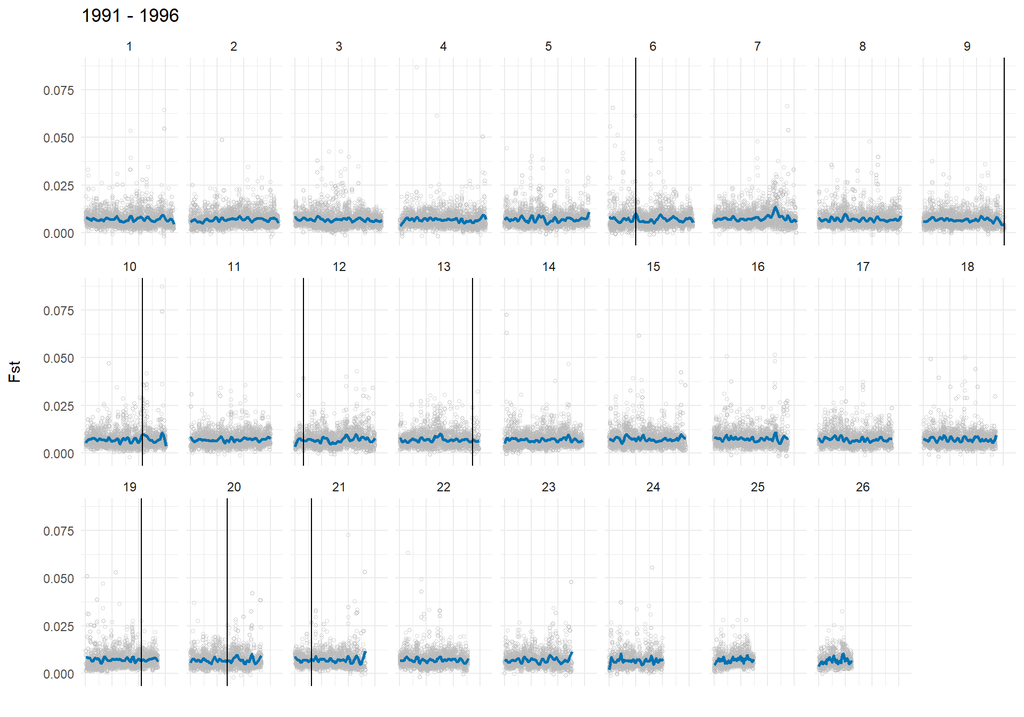

```r
p <- ggplot(fst, aes(x = midPos, y = Fst01)) +
     geom_point(size = 1, color = gry,alpha = 0.6, shape = 1)+
     theme_minimal()+
     theme(axis.text.x=element_blank())+
     ylab("Fst\n")+ xlab("")+
     geom_smooth(method = "loess", se = FALSE, span = 1/10, color = blu)+
     facet_wrap(~chr_num, ncol = 9)+
  ggtitle("1991 - 1996")

p + geom_vline(aes(xintercept = midPos), high_fst)
```

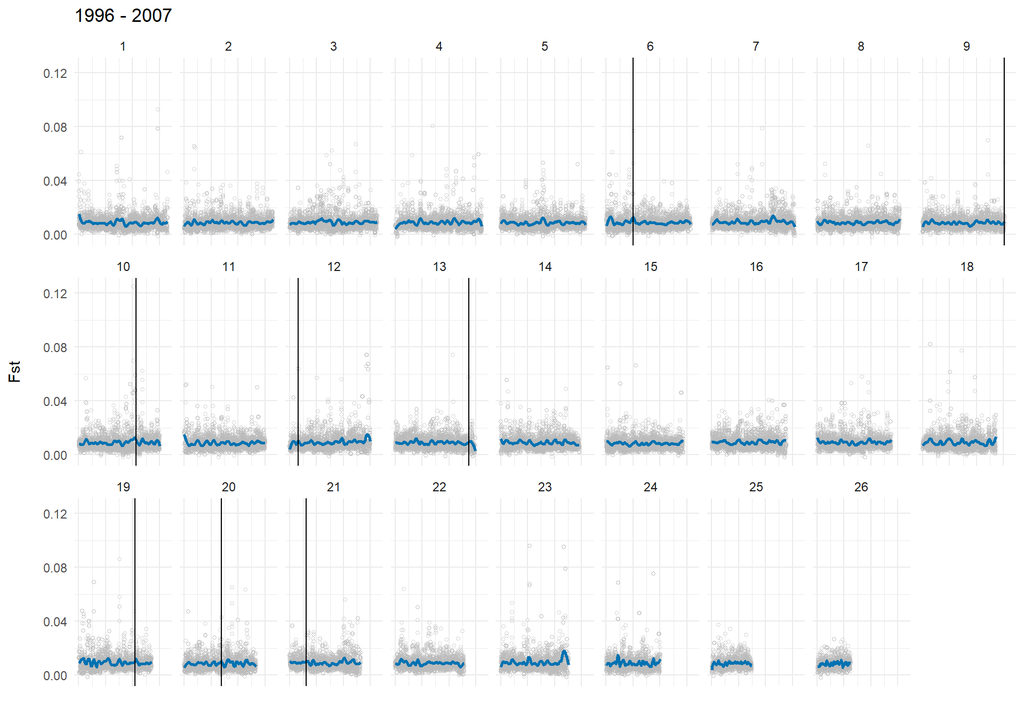

```r
p <- ggplot(fst, aes(x = midPos, y = Fst12)) +
     geom_point(size = 1, color = gry,alpha = 0.6, shape = 1)+
     theme_minimal()+
     theme(axis.text.x=element_blank())+
     ylab("Fst\n")+ xlab("")+
     geom_smooth(method = "loess", se = FALSE, span = 1/10, color = blu)+
     facet_wrap(~chr_num, ncol = 9)+
  ggtitle("1996 - 2007")

p + geom_vline(aes(xintercept = midPos), high_fst)
```

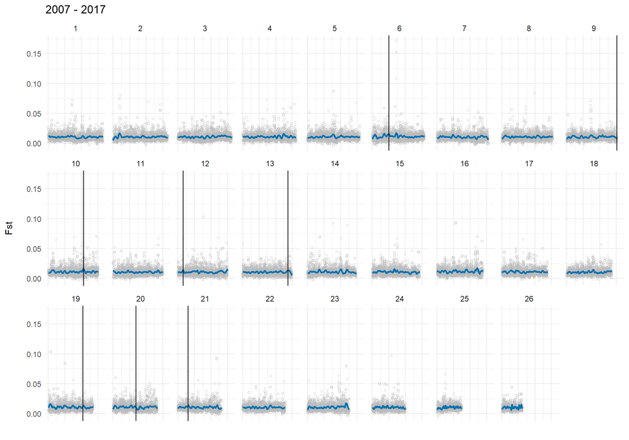

```r
p <- ggplot(fst, aes(x = midPos, y = Fst23)) +
     geom_point(size = 1, color = gry,alpha = 0.6, shape = 1)+
     theme_minimal()+
     theme(axis.text.x=element_blank())+
     ylab("Fst\n")+ xlab("")+
     geom_smooth(method = "loess", se = FALSE, span = 1/10, color = blu)+
     facet_wrap(~chr_num, ncol = 9)+
  ggtitle("2007 - 2017")

p + geom_vline(aes(xintercept = midPos), high_fst)
```